# ROracle : R and Oracle database

Kumar Halake

12 December 2017

Email : halake.kumar22@gmail.com

### ——————————————————————————————————————

### Creating the Connection

```r
driver<- Oracle()
#driver <- dbDriver("Oracle")

 host <- "localhost"
 port <- 1521
 service <- "Orcl1"
 drv <- dbDriver("Oracle")

 connect.string <- paste(

 "(DESCRIPTION=",

 "(ADDRESS=(PROTOCOL=tcp)(HOST=", host, ")(PORT=", port, "))",

 "(CONNECT_DATA=(SERVICE_NAME=", service, ")))", sep = "")

 connection <- dbConnect(drv, username = "system", password = "Oracle_1", dbname = connect.string)


 #connection <- dbConnect(drv = driver, username = "system", password = "Oracle_1")
```

### ——————————————————————————————————————

### Storing and removing some data in database

```r
# Store first 10 rows of iris in Oracle database as an 'iris' table
dbWriteTable(connection, 'IRIS', iris[sample(nrow(iris),10,replace = T),], overwrite = TRUE, row.names = FALSE,col.names = FALSE)
```

```
[1] TRUE
```

```r
# IMP : The Iris data has some columns of type double. When one see the same data in SQL Developer(What I used), the data totally looks different (eg 3.0 in r is 2.9999999 in SQL) So, manipulating may throw error sometimes in R

# If some queries are sending to same table from SQL developer and ROracle connection, sometimes we get error in R, so better to use one at time
```

```sql
 SELECT DISTINCT "Species" FROM IRIS
```

| Species |
| --- |
| versicolor |
| virginica |
| setosa |

```sql
 SELECT * FROM IRIS
```

Displaying records 1 - 10

| Sepal.Length | Sepal.Width | Petal.Length | Petal.Width | Species |
| --- | --- | --- | --- | --- |
| 6.7 | 2.5 | 5.8 | 1.8 | virginica |
| 4.9 | 2.5 | 4.5 | 1.7 | virginica |
| 4.4 | 3.0 | 1.3 | 0.2 | setosa |
| 6.0 | 2.9 | 4.5 | 1.5 | versicolor |
| 5.4 | 3.9 | 1.7 | 0.4 | setosa |
| 5.1 | 3.5 | 1.4 | 0.3 | setosa |
| 6.7 | 2.5 | 5.8 | 1.8 | virginica |
| 4.9 | 3.0 | 1.4 | 0.2 | setosa |
| 6.7 | 2.5 | 5.8 | 1.8 | virginica |
| 5.6 | 2.7 | 4.2 | 1.3 | versicolor |

```r
dbExistsTable(connection,'IRIS')  # Check whether iris table exists? -> TRUE / FALSE
```

```
[1] TRUE
```

```r
dbReadTable(connection, "IRIS") %>% head(n = 10) # Read first 5 rows of iris table in database
```

```
   Sepal.Length Sepal.Width Petal.Length Petal.Width    Species
1           6.7         2.5          5.8         1.8  virginica
2           4.9         2.5          4.5         1.7  virginica
3           4.4         3.0          1.3         0.2     setosa
4           6.0         2.9          4.5         1.5 versicolor
5           5.4         3.9          1.7         0.4     setosa
6           5.1         3.5          1.4         0.3     setosa
7           6.7         2.5          5.8         1.8  virginica
8           4.9         3.0          1.4         0.2     setosa
9           6.7         2.5          5.8         1.8  virginica
10          5.6         2.7          4.2         1.3 versicolor
```

```r
dbRemoveTable(connection,'IRIS')  # Remove the table iris,runs only when no query is running like rs
```

```
[1] TRUE
```

```r
dbExistsTable(connection,'IRIS')  # Whether iris exists yet?
```

```
[1] FALSE
```

### ——————————————————————————————————————

### Importing the ODI data frame from Oracle to R.

Sometimes for any type of explorations (eg:Graphical), one may need to read the entire table from database. It can be achieved by `dbReadTable`. The table imported is in *Dataframe* format. The Field types are accordingly adjusted.

In oracle database the *ODI* dataset already exist.

```r
ODI = dbReadTable(connection, "ODI")
glimpse(ODI)
```

```
Observations: 55,926
Variables: 7
$ COUNTRY   <chr> "Afghanistan", "Afghanistan", "Afghanistan", "Afghan...
$ PLAYER    <chr> "Mohammad Shahzad", "Mohammad Shahzad", "Mohammad Sh...
$ RUNS      <int> 118, 110, 100, 82, 57, 55, 37, 34, 20, 16, 11, 8, 2,...
$ SCORERATE <int> 98, 99, 139, 76, 100, 87, 80, 77, 91, 57, 100, 80, 5...
$ MATCHDATE <dttm> 2010-02-16, 2009-09-01, 2010-08-16, 2010-07-10, 201...
$ GROUND    <chr> "Sharjah CA Stadium", "VRA Ground", "Cambusdoon New ...
$ VERSUS    <chr> "Canada", "Netherlands", "Scotland", "Netherlands", ...
```

```r
head(ODI,n=3)
```

```
      COUNTRY           PLAYER RUNS SCORERATE  MATCHDATE
1 Afghanistan Mohammad Shahzad  118        98 2010-02-16
2 Afghanistan Mohammad Shahzad  110        99 2009-09-01
3 Afghanistan Mohammad Shahzad  100       139 2010-08-16
                 GROUND      VERSUS
1    Sharjah CA Stadium      Canada
2            VRA Ground Netherlands
3 Cambusdoon New Ground    Scotland
```

```r
object.size(ODI)
```

```
2821912 bytes
```

```r
class(ODI)
```

```
[1] "data.frame"
```

```sql
SELECT TO_CHAR(MIN(MATCHDATE),'DDth-Month-YYYY') Begin,TO_CHAR(Max(MATCHDATE),'DDth-Month-YYYY') "End" FROM ODI
```

1 records

| BEGIN | End |
| --- | --- |
| 05TH-January -1971 | 28TH-October -2011 |

### ——————————————————————————————————————

### Some Commands from `ROracle` package

```r
names(dbGetInfo(connection))
```

```
 [1] "username"      "dbname"        "serverVersion" "serverType"
 [5] "resTotal"      "resOpen"       "prefetch"      "bulk_read"
 [9] "bulk_write"    "stmt_cache"    "results"
```

```r
names(dbGetInfo(driver))
```

```
[1] "driverName"      "driverVersion"   "clientVersion"   "conTotal"
[5] "conOpen"         "interruptible"   "unicode_as_utf8" "ora_attributes"
[9] "connections"
```

```r
dbDataType(dbObj = connection,obj = 1:10) # (Dtatype of R object interms of SQL object)
```

```
[1] "INT"
```

```r
dbDataType(dbObj = connection,obj = iris)
```

```
Sepal.Length  Sepal.Width Petal.Length  Petal.Width      Species
    "DOUBLE"     "DOUBLE"     "DOUBLE"     "DOUBLE"       "TEXT"
```

```r
dbDataType(dbObj = connection,obj = "what is it?")
```

```
[1] "TEXT"
```

```r
#dbDataType(dbObj = connection,obj = odi)
dbDataType(ANSI(), 1:5)
```

```
[1] "INT"
```

```r
dbDataType(ANSI(), TRUE)
```

```
[1] "SMALLINT"
```

```r
dbDataType(ANSI(), Sys.Date())
```

```
[1] "DATE"
```

```r
dbDataType(ANSI(), list(raw(10), raw(20)))
```

```
[1] "BLOB"
```

```r
dbDataType(ANSI(), I(3))
```

```
[1] "DOUBLE"
```

```r
dbExistsTable(connection,"ODI") # Chech whether table exixts in
```

```
[1] TRUE
```

```r
dbExistsTable(connection,"Some_datatable")
```

```
[1] FALSE
```

```r
dbListTables(connection) %>% tail(20) # Checking the list of Tables avaiable in Oracle DB.
```

```
 [1] "LOGSTDBY$APPLY_MILESTONE"  "LOGSTDBY$SCN"
 [3] "LOGSTDBY$FLASHBACK_SCN"    "LOGSTDBY$PLSQL"
 [5] "LOGSTDBY$SKIP_TRANSACTION" "LOGSTDBY$SKIP"
 [7] "LOGSTDBY$SKIP_SUPPORT"     "LOGSTDBY$HISTORY"
 [9] "LOGSTDBY$EDS_TABLES"       "DEF$_AQCALL"
[11] "DEF$_AQERROR"              "AQ$_DEF$_AQCALL_F"
[13] "AQ$DEF$_AQCALL"            "AQ$_DEF$_AQERROR_F"
[15] "AQ$DEF$_AQERROR"           "PRODUCT_PRIVS"
[17] "SQLPLUS_PRODUCT_PROFILE"   "HELP"
[19] "ODI"                       "mtcars"
```

```r
dbListFields(connection,'ODI') # Colnames
```

```
[1] "COUNTRY"   "PLAYER"    "RUNS"      "SCORERATE" "MATCHDATE" "GROUND"
[7] "VERSUS"
```

```r
dbListResults(connection) # history
```

```
list()
```

```r
dbGetException(connection) # last error in the connection
```

```
$errorNum
[1] 0

$errorMsg
[1] ""
```

```r
# dbGetInfo(connection)  # Connection details
# dbGetInfo(driver)  #
# dbListConnections(drv = driver) # Get host,port,SID in driver
# dbExecute  # -  number of rows affected by statements
# dbSendQuery
# dbGetQuery =  dbSendQuery() + dbFetch() + dbClearResult

# dbGetRowCount #  Number of rows fetched so far

# dbRemoveTable()
# dbSendStatement()  #  is for DML : UPDATE, DELETE, INSERT INTO, DROP TABLE, ...
# dbGetRowsAffected # - This method returns the number of rows that were added, deleted, or updated by a data manipulation statement

# dbWriteTable #  read data in Oracle database
# dbReadTable
# dbRemoveTable
# fetch  # fetching certain number of instances
# dbFetch
# dbHasCompleted #  This method returns if the operation has completed. A SELECT query is completed if all rows have been fetched. A data manipulation statement is always completed.

# dbIsValid # Is this DBMS object still valid?

# dbBegin # savepoint
# dbBreak
# dbCommit
# dbRollback
# dbWithTransaction()
# sqlAppendTable #  Insert rows into a tabl
# sqlCreateTable #  Create a simple table
# sqlData #  Convert a data frame into form suitable for upload to an SQL database
# transactions # Begin/commit/rollback SQL transactions
# dbDisconnect()  # Disconnect R from Oracle database
```

Sometimes data may be having larger in size,importing a large volume of data in R is not recommended. So just querrying by letting it in database itself is a better choice.

### ——————————————————————————————————————

### SQL Queries

- *Note that the reslut of any SQL query may not be completely displayed in html outpot*

#### number of matches

```sql
SELECT COUNT(*) FROM ODI /* number of matches */
```

| COUNT(*) |
| --- |
| 55926 |

#### Countrywise average runs

```sql
SELECT COUNTRY, AVG(RUNS) as avg_runs FROM ODI GROUP BY COUNTRY
```

Displaying records 1 - 10

| COUNTRY | AVG_RUNS |
| --- | --- |
| Ireland | 20.50801 |
| Kenya | 17.73057 |
| South Africa | 25.68711 |
| West Indies | 22.63222 |
| Zimbabwe | 19.79050 |
| East Africa | 9.90625 |
| United Arab Emirates | 14.07018 |
| New Zealand | 21.06679 |
| Pakistan | 22.71946 |
| Scotland | 16.20961 |

#### Merging fields

```sql
SELECT COUNTRY||AVG(RUNS) as Country_avg_Runs FROM ODI GROUP BY COUNTRY
```

| COUNTRY_AVG_RUNS |
| --- |
| Ireland20.5080128205128205128205128205128205128 |
| Kenya17.7305737109658678286129266521423384169 |
| South Africa25.6871118012422360248447204968944099379 |
| West Indies22.6322232223222322232223222322232223222 |
| Zimbabwe19.7904961932265686531898135993699133631 |
| East Africa9.90625 |
| United Arab Emirates14.0701754385964912280701754385964912281 |
| New Zealand21.0667893284268629254829806807727690892 |
| Pakistan22.7194604425583510154592300697180963929 |
| Scotland16.2096069868995633187772925764192139738 |

```sql
SELECT GROUND||'-'||cOUNT(GROUND) FROM ODI GROUP BY GROUND
```

| GROUND\|\|‘-’\|\|COUNT(GROUND) |
| --- |
| Cambusdoon New Ground-100 |
| OUTsurance Oval-409 |
| Brisbane Cricket Ground-1184 |
| Marrara Cricket Ground-72 |
| Mahinda Rajapaksha International-76 |
| Telstra Dome-225 |
| Westpac Stadium-318 |
| Nehru Stadium (Guwahati)-244 |
| Kingsmead-642 |
| Edgbaston-787 |

```sql
SELECT GROUND||'-'||cOUNT(GROUND) AS "GROUNDWISE COUNT" FROM ODI GROUP BY GROUND ORDER BY COUNT(GROUND) DESC
```

| GROUNDWISE COUNT |
| --- |
| Sharjah CA Stadium-3581 |
| Sydney Cricket Ground-2462 |
| Melbourne Cricket Ground-2308 |
| R. Premadasa Stadium-1797 |
| Harare Sports Club-1784 |
| Adelaide Oval-1262 |
| W.A.C.A. Ground-1222 |
| Brisbane Cricket Ground-1184 |
| Gymkhana Club Ground-1123 |
| Eden Park-1100 |

```sql
SELECT COUNTRY ||' vs '|| VERSUS ||' at '|| GROUND ||' - ' || COUNT(GROUND) AS "Country-Versus-Ground-n" FROM ODI GROUP BY COUNTRY,VERSUS,GROUND ORDER BY COUNT(GROUND) DESC
```

| Country-Versus-Ground-n |
| --- |
| Sri Lanka vs Pakistan at Sharjah CA Stadium - 294 |
| Pakistan vs Sri Lanka at Sharjah CA Stadium - 287 |
| West Indies vs Australia at Melbourne Cricket Ground - 245 |
| West Indies vs Australia at Sydney Cricket Ground - 241 |
| Sri Lanka vs India at R. Premadasa Stadium - 241 |
| India vs Sri Lanka at R. Premadasa Stadium - 239 |
| Australia vs West Indies at Melbourne Cricket Ground - 234 |
| Australia vs West Indies at Sydney Cricket Ground - 231 |
| India vs Pakistan at Sharjah CA Stadium - 221 |
| Pakistan vs India at Sharjah CA Stadium - 204 |

### ——————————————————————————————————————

#### Data related to India

```sql
SELECT*FROM ODI WHERE COUNTRY = 'India' /*  Only first 10 rows are displayed */
```

Displaying records 1 - 10

| COUNTRY | PLAYER | RUNS | SCORERATE | MATCHDATE | GROUND | VERSUS |
| --- | --- | --- | --- | --- | --- | --- |
| India | Sachin R Tendulkar | 200 | 136 | 2010-02-24 | Captain Roop Singh Stadium | South Africa |
| India | Sachin R Tendulkar | 186 | 124 | 1999-11-08 | Lal Bahadur Shastri Stadium | New Zealand |
| India | Sachin R Tendulkar | 175 | 124 | 2009-11-05 | Rajiv Gandhi International Stadium | Australia |
| India | Sachin R Tendulkar | 163 | 123 | 2009-03-08 | AMI Stadium | New Zealand |
| India | Sachin R Tendulkar | 152 | 101 | 2003-02-23 | City Oval | Namibia |
| India | Sachin R Tendulkar | 146 | 95 | 2000-12-08 | Barkatullah Khan Stadium | Zimbabwe |
| India | Sachin R Tendulkar | 146 | 111 | 2001-10-24 | Boland Bank Park | Kenya |
| India | Sachin R Tendulkar | 143 | 109 | 1998-04-22 | Sharjah CA Stadium | Australia |
| India | Sachin R Tendulkar | 141 | 104 | 2004-03-16 | Rawalpindi Cricket Stadium | Pakistan |
| India | Sachin R Tendulkar | 141 | 95 | 2006-09-14 | Kinrara Academy Oval | West Indies |

#### Maximum runs by India versus all countries it played and the corresponding player

```sql
SELECT COUNTRY,VERSUS,PLAYER,RUNS FROM ODI WHERE RUNS IN
(SELECT MAX(RUNS) AS RUNS FROM ODI WHERE COUNTRY='India' GROUP BY VERSUS) AND COUNTRY = 'India' ORDER BY RUNS DESC
```

Displaying records 1 - 10

| COUNTRY | VERSUS | PLAYER | RUNS |
| --- | --- | --- | --- |
| India | South Africa | Sachin R Tendulkar | 200 |
| India | New Zealand | Sachin R Tendulkar | 186 |
| India | Sri Lanka | Sourav C Ganguly | 183 |
| India | Sri Lanka | Mahendra S Dhoni | 183 |
| India | Australia | Sachin R Tendulkar | 175 |
| India | Zimbabwe | Kapil Dev | 175 |
| India | Bangladesh | Virender Sehwag | 175 |
| India | Namibia | Sachin R Tendulkar | 152 |
| India | Pakistan | Mahendra S Dhoni | 148 |
| India | Zimbabwe | Sachin R Tendulkar | 146 |

- Is it correct output ? Check how many opponent countries are there for India. They are 20 not 132

```sql
SELECT COUNT(*) FROM (SELECT COUNTRY,VERSUS,PLAYER,RUNS FROM ODI WHERE RUNS IN
(SELECT MAX(RUNS) AS RUNS FROM ODI WHERE COUNTRY='India' GROUP BY VERSUS) AND COUNTRY = 'India' ORDER BY RUNS DESC)
```

| COUNT(*) |
| --- |
| 132 |

```sql
SELECT COUNT(DISTINCT VERSUS) FROM ODI WHERE COUNTRY = 'India'
```

| COUNT(DISTINCTVERSUS) |
| --- |
| 20 |

```sql
SELECT o.COUNTRY, o.VERSUS,o.MATCHDATE,o.PLAYER,o.RUNS FROM ODI o JOIN
(SELECT COUNTRY,VERSUS, MAX(RUNS) AS highest_runs FROM ODI WHERE COUNTRY = 'India' GROUP BY COUNTRY,VERSUS) d
ON o.COUNTRY=d.COUNTRY AND o.VERSUS = d.VERSUS AND o.RUNS = d.highest_runs ORDER BY o.RUNS DESC
```

Displaying records 1 - 10

| COUNTRY | VERSUS | MATCHDATE | PLAYER | RUNS |
| --- | --- | --- | --- | --- |
| India | South Africa | 2010-02-24 | Sachin R Tendulkar | 200 |
| India | New Zealand | 1999-11-08 | Sachin R Tendulkar | 186 |
| India | Sri Lanka | 1999-05-26 | Sourav C Ganguly | 183 |
| India | Sri Lanka | 2005-10-31 | Mahendra S Dhoni | 183 |
| India | Australia | 2009-11-05 | Sachin R Tendulkar | 175 |
| India | Zimbabwe | 1983-06-18 | Kapil Dev | 175 |
| India | Bangladesh | 2011-02-19 | Virender Sehwag | 175 |
| India | Namibia | 2003-02-23 | Sachin R Tendulkar | 152 |
| India | Pakistan | 2005-04-05 | Mahendra S Dhoni | 148 |
| India | Kenya | 2001-10-24 | Sachin R Tendulkar | 146 |

- 21 rows because same highest runs in 1999 and 2005 by **Sourav C Ganguly** and **Mahendra S Dhoni** respectively against **Sri Lanka**

### ——————————————————————————————————————

#### Maximum runs of each player and the country he belongs to

```sql
SELECT COUNTRY,PLAYER,MAX(RUNS) AS RUNS FROM ODI GROUP BY COUNTRY,PLAYER
```

Displaying records 1 - 10

| COUNTRY | PLAYER | RUNS |
| --- | --- | --- |
| Afghanistan | Mohammad Nabi | 62 |
| Afghanistan | Karim Sadiq | 114 |
| Afghanistan | Aftab Alam | 6 |
| Australia | Brett Lee | 57 |
| Australia | John Dyson | 79 |
| Australia | Bradley J Hodge | 123 |
| Australia | Adam C Voges | 80 |
| Australia | Michael J Di Venuto | 89 |
| Australia | Brendon P Julian | 35 |
| Australia | Julien M Wiener | 50 |

#### Country ever having more runs than max runs by India

```sql
SELECT COUNTRY,RUNS FROM ODI WHERE RUNS > (SELECT MAX(RUNS) AS RUNS FROM ODI WHERE COUNTRY = 'India' GROUP BY COUNTRY) /* No country */
```

Table: 0 records

COUNTRY RUNS ——– —–

- The same result is achieved by JOIN also. Joins are recommended over nested Subqueries like above

```sql
SELECT o.COUNTRY,O.RUNS FROM ODI o JOIN
(SELECT COUNTRY,MAX(RUNS) AS max_run FROM ODI WHERE COUNTRY = 'India' GROUP BY COUNTRY) b
ON o.COUNTRY = b.COUNTRY AND o.RUNS >b.max_run
/* No country, by putting >=, will get India only */
```

Table: 0 records

COUNTRY RUNS ——– —–

### ——————————————————————————————————————

#### Score rate variation for different Countries

```sql
SELECT COUNTRY, stddev(SCORERATE) sd FROM ODI GROUP BY COUNTRY ORDER BY sd
```

Displaying records 1 - 10

| COUNTRY | SD |
| --- | --- |
| East Africa | 18.37641 |
| Hong Kong | 29.88540 |
| United States | 30.54528 |
| United Arab Emirates | 34.18290 |
| Bangladesh | 40.40986 |
| Kenya | 40.81031 |
| Zimbabwe | 41.98671 |
| Sri Lanka | 42.08557 |
| Namibia | 42.53942 |
| England | 42.73910 |

### ——————————————————————————————————————

### R QUERIES

#### Fetch and save in R

Here, the previous SQL query output is saved in R as dataframe, so one can use to to explore in different ways like graphs.

```r
df <- dbGetQuery(connection,"SELECT DISTINCT TO_CHAR(MATCHDATE,'YYYY') FROM ODI")
class(df)       # It is dataframe
```

```
[1] "data.frame"
```

```r
typeof(df)
```

```
[1] "list"
```

```r
colnames(df)  # default column name
```

```
[1] "TO_CHAR(MATCHDATE,'YYYY')"
```

```r
class(df$`TO_CHAR(MATCHDATE,'YYYY')`)  # It is character
```

```
[1] "character"
```

```r
head(df)
```

```
  TO_CHAR(MATCHDATE,'YYYY')
1                      2005
2                      2003
3                      2000
4                      2001
5                      1997
6                      1987
```

```r
object.size(df)
```

```
2992 bytes
```

### ——————————————————————————————————————

#### Monthwise number of matches

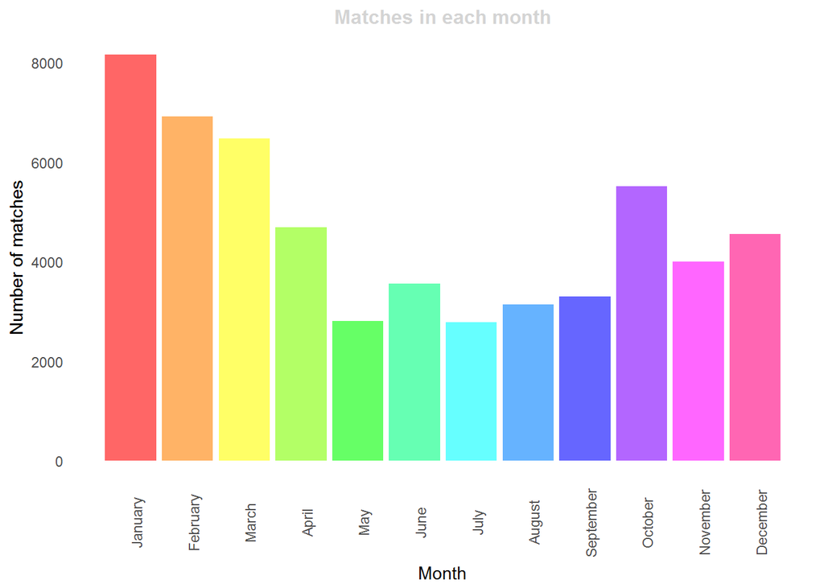

```r
  dbGetQuery(connection,statement = "SELECT TO_CHAR(MATCHDATE,'mm') MONTH FROM ODI") %>%
  ggplot() +
  geom_bar(aes(x = as.numeric(MONTH)),stat = "count",fill = rainbow(12),alpha = 0.6) +
  theme(panel.grid = element_blank(),panel.background = element_blank(),
        axis.ticks = element_blank(),axis.text.x = element_text(angle = 90))+
  scale_x_discrete(limits = 1:12, labels = month.name) +
  labs(y = "Number of matches", x = "Month", title = "Matches in each month")+
  theme(plot.title = element_text(face = "bold",color = "gray83",hjust = 0.5,size = 12))
```

### ——————————————————————————————————————

#### Number of matches per Year and month

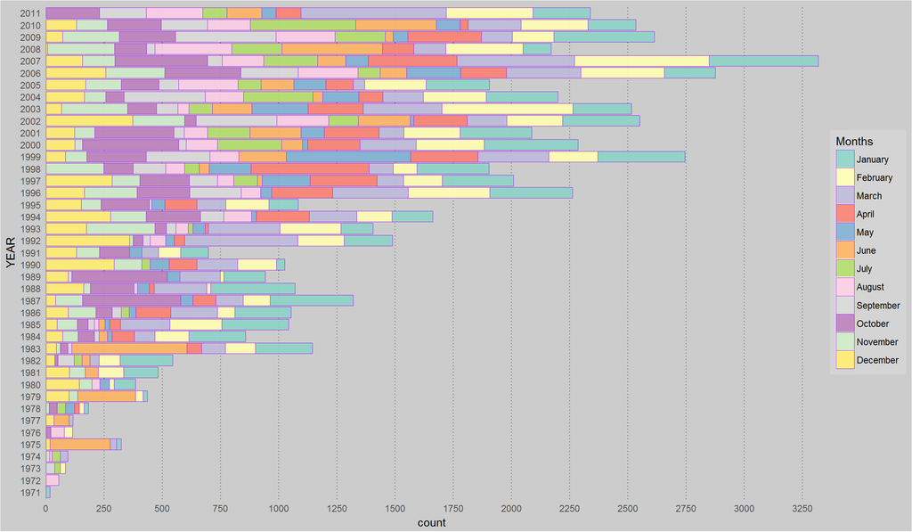

```r
dbGetQuery(connection,"SELECT TO_CHAR(MATCHDATE,'YYYY') YEAR, TO_CHAR(MATCHDATE,'MM') MONTH FROM ODI") %>%
  ggplot() +
  geom_bar(aes(x = YEAR,fill = as.factor(MONTH)), stat = "count",color = "purple",alpha = 0.9,size = 0.04) +
  theme(axis.text.x.top = element_text(angle = 90),
        panel.background = element_rect(fill = "gray80"),
        plot.background = element_rect(fill = "gray80"),
        axis.ticks = element_blank(),
        legend.background = element_rect(fill = "gray83"),
        panel.grid.major.y = element_blank(),
        panel.grid.minor.x = element_blank(),
        panel.grid.major.x = element_line(colour = "gray40",linetype = 3,lineend = 'butt')) +
  scale_y_continuous(expand = c(0.0,0),breaks = seq(0,3500,by = 250)) +
  scale_fill_brewer(name = 'Months',labels = month.name,palette = "Set3",direction = 1) +
  coord_flip()
```

- Normally in any given year, most number of matches were played in first quarter
- 1971 and 1972 are the beginning years where match happened only in a single monthyear
- From the year 1991 we see some seasonal pattern interms of yerly number of matches. (the number of matches are relatively less in 1991, but in next consecutive 3 years it increased. Again number reduced in 1995 and tremendous increase in next 3 years)

### ——————————————————————————————————————

#### India’s highest runs against different opponents

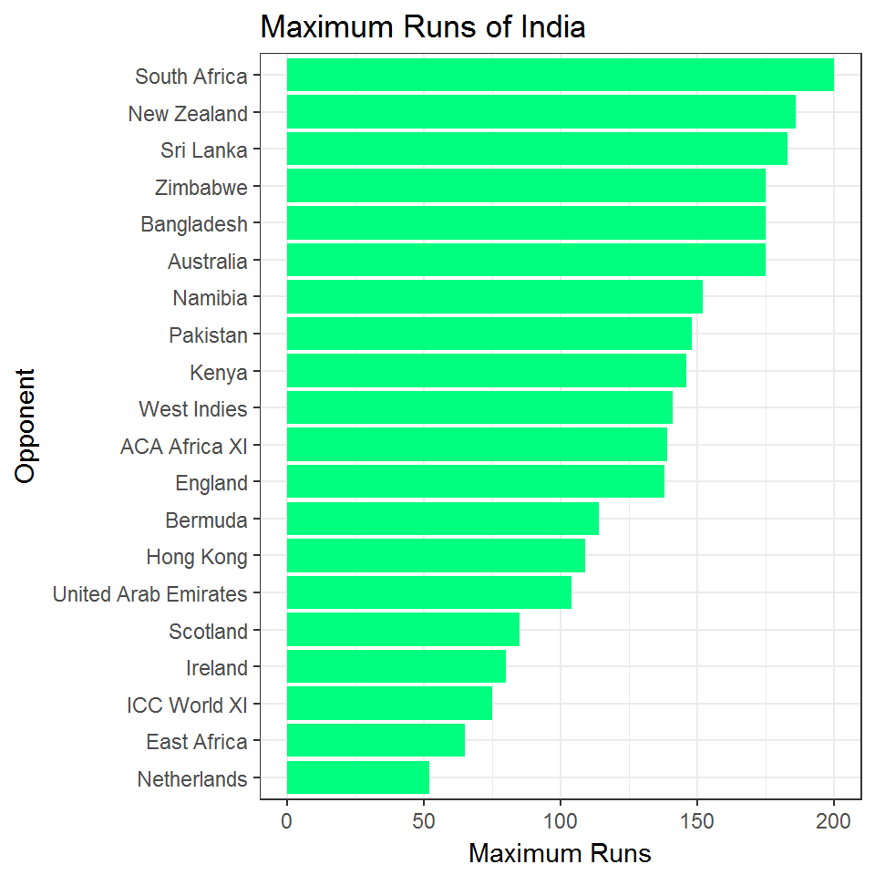

```r
dbGetQuery(connection,
"SELECT o.COUNTRY, o.VERSUS,o.MATCHDATE,o.PLAYER,o.RUNS FROM ODI o JOIN
(SELECT COUNTRY,VERSUS, MAX(RUNS) AS highest_runs FROM ODI WHERE COUNTRY = 'India' GROUP BY COUNTRY,VERSUS) d
ON o.COUNTRY=d.COUNTRY AND o.VERSUS = d.VERSUS AND o.RUNS = d.highest_runs ORDER BY o.RUNS DESC") %>%
  group_by(VERSUS) %>% summarise(RUNS = mean(RUNS)) %>% # Srilanka is twice,we need unique so
  ggplot() + geom_bar(aes(x = reorder(VERSUS,RUNS), y = RUNS),stat = "identity",fill = "springgreen") +
  labs(x="Opponent", y ="Maximum Runs",title = "Maximum Runs of India") + coord_flip() +
  theme_bw()
```

### ——————————————————————————————————————

#### Top number of centuries

```sql
SELECT PLAYER,COUNT(PLAYER) CENTURY FROM ODI WHERE RUNS >= 100 GROUP BY PLAYER ORDER BY CENTURY DESC FETCH NEXT 21 ROWS ONLY
```

Displaying records 1 - 10

| PLAYER | CENTURY |
| --- | --- |
| Sachin R Tendulkar | 48 |
| Ricky T Ponting | 30 |
| Sanath T Jayasuriya | 28 |
| Sourav C Ganguly | 22 |
| Herschelle H Gibbs | 21 |
| Saeed Anwar | 20 |
| Christopher H Gayle | 19 |
| Brian C Lara | 19 |
| Mark E Waugh | 18 |
| Desmond L Haynes | 17 |

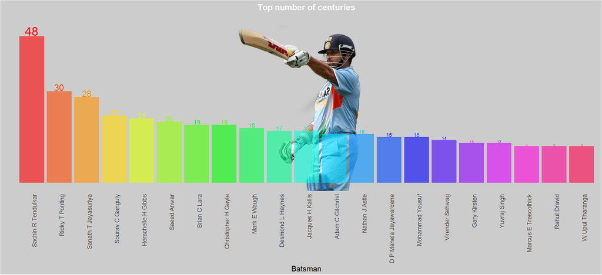

```r
img <- readPNG("sachin-transpa-2.png")
g <- rasterGrob(img, interpolate=TRUE)

  dbGetQuery(connection,
             statement = "SELECT PLAYER,COUNT(PLAYER) CENTURY FROM ODI WHERE RUNS >= 100 GROUP BY PLAYER ORDER BY CENTURY DESC FETCH NEXT 21 ROWS ONLY") %>%
  ggplot(aes(x = reorder(PLAYER,desc(CENTURY)),y = CENTURY)) +
    annotation_custom(g, xmin=-Inf, xmax=Inf, ymin=-Inf, ymax=Inf) +
    geom_bar(stat = "identity",fill = rainbow(21),alpha = 0.6) +
    geom_text(aes(label = CENTURY,size =CENTURY),show.legend = FALSE,vjust = - 0.09,color = rainbow(21)) +
    theme(panel.grid = element_blank(),
          panel.background = element_rect(fill = "gray80"),
          plot.background = element_rect(fill = "gray80"),
          axis.ticks = element_blank(),axis.text.x = element_text(angle = 90,hjust = 1.0)) +
    scale_y_continuous(limits = c(0,52),labels = NULL) +
    labs(y = "", x = "Batsman", title = "Top number of centuries") +
    theme(plot.title = element_text(face = "bold",color = "white",hjust = 0.5,size = 12))
```

### ——————————————————————————————————————

#### Some functions `dbSendQuery`,`dbGetStatement`,`dbGetRowsAffected`,`fetch`

```r
q = "SELECT COUNTRY,VERSUS,PLAYER,RUNS FROM ODI WHERE COUNTRY = 'India'"

rs = dbSendQuery(connection,q)
rs
```

```
Statement:            SELECT COUNTRY,VERSUS,PLAYER,RUNS FROM ODI WHERE COUNTRY = 'India'
Rows affected:        0
Row count:            0
Select statement:     TRUE
Statement completed:  FALSE
OCI prefetch:         FALSE
Bulk read:            1000
Bulk write:           1000
```

```r
dbGetStatement(rs)
```

```
[1] "SELECT COUNTRY,VERSUS,PLAYER,RUNS FROM ODI WHERE COUNTRY = 'India'"
```

```r
dbGetRowsAffected(rs)
```

```
[1] 0
```

```r
dbColumnInfo(rs)
```

```
     name    Sclass     type len precision scale nullOK
1 COUNTRY character VARCHAR2 100         0     0   TRUE
2  VERSUS character VARCHAR2 100         0     0   TRUE
3  PLAYER character VARCHAR2 100         0     0   TRUE
4    RUNS   integer   NUMBER  NA         3     0   TRUE
```

```r
dbHasCompleted(rs)
```

```
[1] FALSE
```

```r
fetched1 = fetch(rs,25) # Once first n instances are fetched, they wont be fetched again,In the next fetch, fetching start from next instance only. If no mention of n, all instances are fetched

fetched2 = fetch(rs) # If dont give n, it will fetch remaining instances from DBIresult as a subset : fetch2

dbHasCompleted(rs)
```

```
[1] TRUE
```

```r
fetched1 # dont forget, It is dataframe
```

```
   COUNTRY       VERSUS             PLAYER RUNS
1    India South Africa Sachin R Tendulkar  200
2    India  New Zealand Sachin R Tendulkar  186
3    India    Australia Sachin R Tendulkar  175
4    India  New Zealand Sachin R Tendulkar  163
5    India      Namibia Sachin R Tendulkar  152
6    India     Zimbabwe Sachin R Tendulkar  146
7    India        Kenya Sachin R Tendulkar  146
8    India    Australia Sachin R Tendulkar  143
9    India     Pakistan Sachin R Tendulkar  141
10   India  West Indies Sachin R Tendulkar  141
11   India    Australia Sachin R Tendulkar  141
12   India        Kenya Sachin R Tendulkar  140
13   India    Australia Sachin R Tendulkar  139
14   India    Sri Lanka Sachin R Tendulkar  138
15   India    Sri Lanka Sachin R Tendulkar  137
16   India    Australia Sachin R Tendulkar  134
17   India    Sri Lanka Sachin R Tendulkar  128
18   India        Kenya Sachin R Tendulkar  127
19   India     Zimbabwe Sachin R Tendulkar  127
20   India     Zimbabwe Sachin R Tendulkar  124
21   India     Pakistan Sachin R Tendulkar  123
22   India South Africa Sachin R Tendulkar  122
23   India  West Indies Sachin R Tendulkar  122
24   India    Sri Lanka Sachin R Tendulkar  120
25   India      England Sachin R Tendulkar  120
```

```r
fetched = rbind(fetched1,fetched2) # At the begining itself would have used fetched = fetch(rs)

dbGetRowCount(rs)  # s the number of rows fetched so far.
```

```
[1] 6609
```

```r
dbClearResult(rs)  # after setting dbClearResult(rs); print(rs)  produces an error, as it is cleared
```

```
[1] TRUE
```

Fetching is helpful when there is limitation on fetching instances from database

### ——————————————————————————————————————

#### Top 20 Indian player’s interms of average score rate

```sql
SELECT COUNTRY,PLAYER,AVG(SCORERATE) AS AVG_SCORE_RATE FROM ODI WHERE COUNTRY = 'India' GROUP BY COUNTRY,PLAYER  ORDER BY AVG_SCORE_RATE DESC FETCH NEXT 20 ROWS ONLY
/* FETCH FIRST 20 ROWS ONLY */
```

Displaying records 1 - 10

| COUNTRY | PLAYER | AVG_SCORE_RATE |
| --- | --- | --- |
| India | Paras L Mhambrey | 140.00000 |
| India | Joginder Sharma | 133.00000 |
| India | Prashant S Vaidya | 116.50000 |
| India | Subroto T Banerjee | 102.20000 |
| India | Saradindu P Mukherjee | 100.00000 |
| India | Pankaj Dharmani | 100.00000 |
| India | Pankaj Singh | 100.00000 |
| India | Umesh Yadav | 100.00000 |
| India | Yusuf K Pathan | 95.85366 |
| India | Virender Sehwag | 93.91739 |

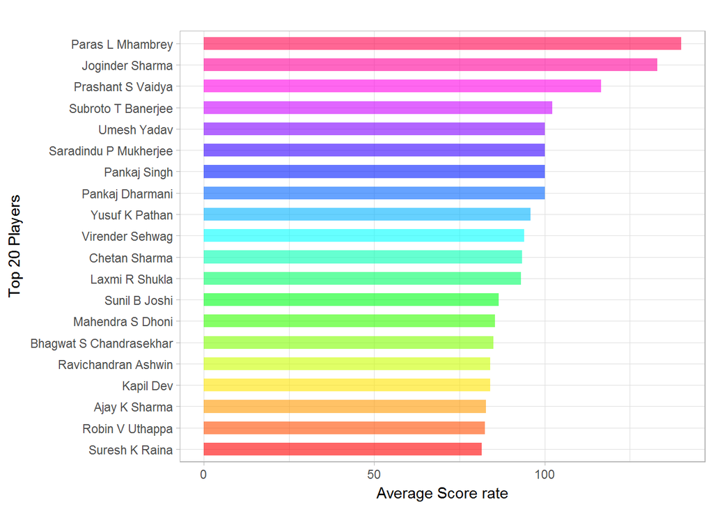

```r
q = "SELECT COUNTRY,PLAYER,AVG(SCORERATE) AS AVG_SCORE_RATE FROM ODI WHERE COUNTRY = 'India' GROUP BY COUNTRY,PLAYER  ORDER BY AVG_SCORE_RATE DESC"
rs = dbSendQuery(connection,q)
fetch(rs,20) %>% ggplot() +
  geom_bar(aes(x = reorder(PLAYER,AVG_SCORE_RATE),y = AVG_SCORE_RATE),
           stat="identity",fill = rainbow(20),width = .6,alpha = 0.6) +
  labs(x = "Top 20 Players",y = "Average Score rate",title ="") + coord_flip() + theme_light()
```

```r
dbClearResult(rs)
```

```
[1] TRUE
```

### ——————————————————————————————————————

#### Top Players interms of average score rate for all countries

There are some players who played once or twice and their score rate would be either very high or very low. So we consider a player who played more than 5 ODI’s (This choice is subjective, so please no question - *WHY 5?*)

```sql
 SELECT COUNT(*) FROM (SELECT COUNTRY,PLAYER, AVG(SCORERATE) AVG_SCORE_RATE,COUNT(*) MATCHES FROM ODI GROUP BY COUNTRY,PLAYER)
```

| COUNT(*) |
| --- |
| 1937 |

```sql
SELECT COUNT(*) FROM (SELECT COUNTRY,PLAYER, AVG(SCORERATE) AVG_SCORE_RATE,COUNT(*) MATCHES FROM ODI HAVING COUNT(*) > 5 GROUP BY COUNTRY,PLAYER)
```

| COUNT(*) |
| --- |
| 1174 |

```
Almost 763 Players played 5 or less matches
```

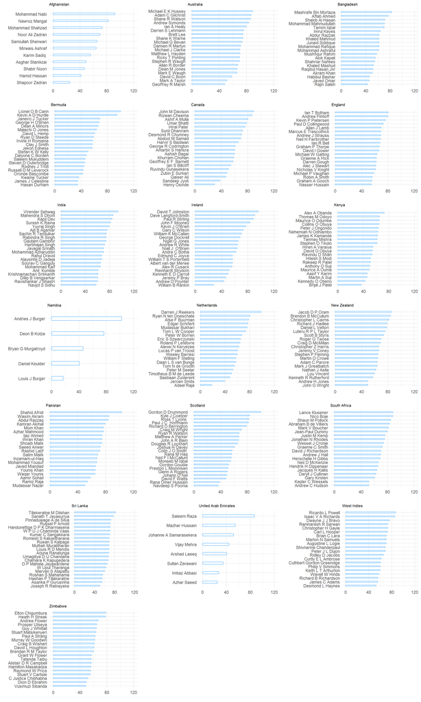

```r
q = "SELECT COUNTRY,PLAYER, AVG(SCORERATE) AVG_SCORE_RATE,COUNT(*) MATCHES FROM ODI HAVING COUNT(*) > 5 GROUP BY COUNTRY,PLAYER"
rs = dbSendQuery(connection,q)
fetched = fetch(rs) #dbFetch is also useful
country_list = split(x = fetched,f = fetched$COUNTRY)

top_20_each <- lapply(X = country_list, FUN = function(x) top_n(x,20))

g = list()
j = 1
while(j <= length(top_20_each)){
  for(i in names(top_20_each)){
    g[[j]] = ggplot(top_20_each[[i]],aes(x = reorder(PLAYER,AVG_SCORE_RATE),y = AVG_SCORE_RATE)) +
      geom_bar(stat = "identity",width = 0.25,fill = "white",color = "steelblue1") +
      scale_y_continuous(breaks = seq(0,120,by = 40),limits = c(0,120),labels = seq(0,120,by = 40)) +
      labs(x = "",y = "",title = i) +
      theme_minimal() +
      theme(plot.title = element_text(size = 8),axis.title = element_text(size = 7)) +
      coord_flip()
    j = j+1
  }
}

do.call(gridExtra::grid.arrange,c(g,ncol = 3))
```

```r
dbClearResult(rs)
```

```
[1] TRUE
```

### ——————————————————————————————————————

#### Correlation between Runs and scorerate for England Players

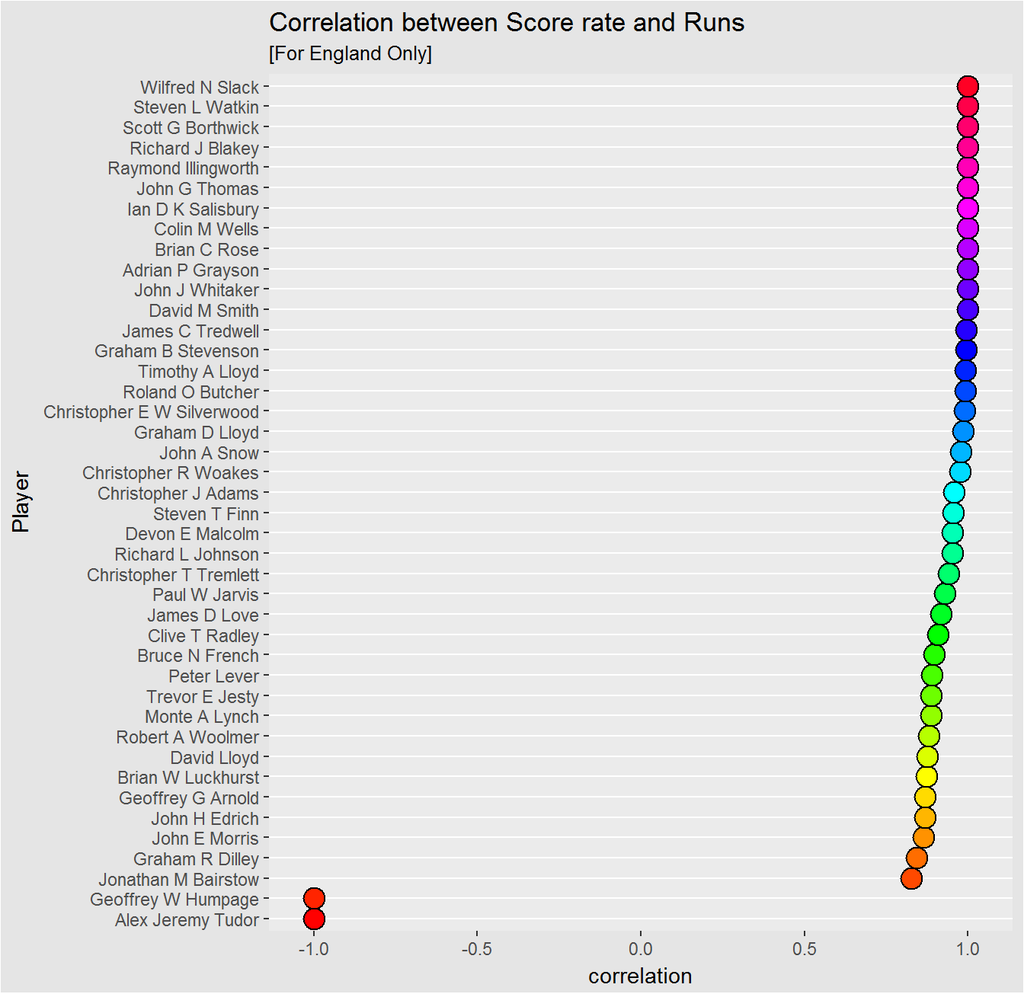

```r
q = "SELECT PLAYER,RUNS,SCORERATE FROM ODI WHERE COUNTRY = 'England'"

dbGetQuery(connection,statement = q) %>%
  group_by(PLAYER) %>%
  summarise(correlation = cor(RUNS,SCORERATE)) %>%
  filter(abs(correlation) > 0.8) %>%
  ggplot(aes(x = reorder(PLAYER,correlation),y = correlation)) +
  geom_dotplot(binaxis='y', stackdir='center',
           stat = "identity",radius = 0.2, fill = rainbow(42)) +
  labs(x = "Player",title = "Correlation between Score rate and Runs",subtitle = "[For England Only]") +
  theme(panel.grid.major.x = element_blank(),
        panel.grid.minor.x = element_blank(),
        plot.background = element_rect(fill = "gray90")) +
  coord_flip()
```

```r
# dbGetQuery(connection,statement = q) %>%
#   group_by(PLAYER) %>%
#   summarise(correlation = cor(RUNS,SCORERATE)) %>%
#   filter(abs(correlation) > 0.8) %>%
#   ggplot(aes(x = reorder(PLAYER,correlation),y = correlation)) +
#   geom_point(size = 5, color = rainbow(42),pch =19) +
#   labs(x = "Player",title = "Correlation between Score rate and Runs") +
#   theme(panel.grid = element_blank(),plot.background = element_rect(fill = "gray90")) +
#   coord_flip()
```

Here we have noticed two outliers, *Alex Jeremy Tudor* and *Geoffrey W Humpage*, whose correlation is perfect -ve.

### ——————————————————————————————————————

```r
q = "SELECT*FROM ODI WHERE COUNTRY = 'England' AND PLAYER IN ('Alex Jeremy Tudor','Geoffrey W Humpage')"
rs = dbSendQuery(connection,q)
outliers = dbFetch(res = rs, n = -1)
outliers= mutate(outliers,balls_faced = SCORERATE*RUNS/100)
outliers
```

```
  COUNTRY             PLAYER RUNS SCORERATE  MATCHDATE       GROUND
1 England Geoffrey W Humpage    6        43 1981-06-08   Headingley
2 England Geoffrey W Humpage    5        50 1981-06-06    Edgbaston
3 England  Alex Jeremy Tudor    6        67 2002-07-07 Old Trafford
4 England  Alex Jeremy Tudor    3       150 2002-07-09     The Oval
     VERSUS balls_faced
1 Australia        2.58
2 Australia        2.50
3 Sri Lanka        4.02
4     India        4.50
```

```r
dbClearResult(rs)
```

```
[1] TRUE
```

This is because both the players played only in 1981 and 2002 and not even played for a complete over.

#### The rare players

Number of players played only once (In time period from 1971 to 2011)

```r
q = "SELECT COUNTRY,PLAYER,COUNT(PLAYER) AS MATCHES  FROM ODI GROUP BY COUNTRY,PLAYER HAVING COUNT(PLAYER) = 1"
rs = dbSendQuery(connection,q)
rare = dbFetch(res = rs, n = -1)
rare %>% group_by(COUNTRY) %>% summarise(rare_players = sum(MATCHES)) %>% arrange(desc(rare_players))
```

```
# A tibble: 20 x 2
                COUNTRY rare_players
                  <chr>        <dbl>
 1             Pakistan           28
 2            Australia           24
 3                India           23
 4              England           21
 5          New Zealand           17
 6            Sri Lanka           17
 7          West Indies           17
 8           Bangladesh           14
 9               Canada           10
10 United Arab Emirates           10
11         South Africa            9
12             Zimbabwe            9
13          Afghanistan            7
14          Netherlands            5
15            Hong Kong            3
16        United States            3
17              Bermuda            2
18          East Africa            2
19              Ireland            2
20             Scotland            2
```

```r
dbClearResult(rs)
```

```
[1] TRUE
```

Totally 225 players in ODI from 1971 to 2011 played once.

### ——————————————————————————————————————

#### Long time career in ODI

Note that this is different than the number of ODI’s played

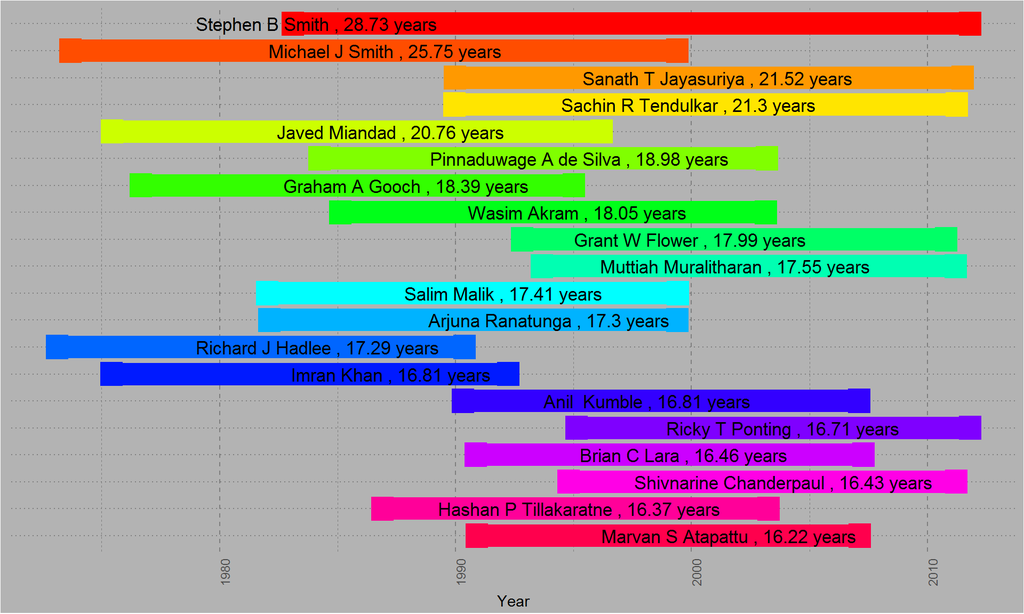

```r
q = 'SELECT PLAYER ,BEGIN,"END",MED,"END" - BEGIN AS DAYS,("END" - BEGIN)/365 AS YEAR FROM
(SELECT PLAYER,MIN(MATCHDATE) BEGIN,MAX(MATCHDATE) "END",MEDIAN(MATCHDATE) MED FROM ODI GROUP BY PLAYER) ORDER BY YEAR DESC FETCH NEXT 20 ROWS ONLY'
# aes(x = reorder(PLAYER,DIFF),y=DIFF)
rs = dbSendQuery(connection,q)
dbFetch(rs,n= -1) %>% ggplot() +
  geom_errorbar(aes(x = reorder(PLAYER,YEAR),ymin=BEGIN,ymax = END),stat="identity",size = 7.5,color = rainbow(20))+
  geom_text(aes(x = reorder(PLAYER,YEAR),y=MED,label = paste(PLAYER,',',round(YEAR,2),'years'),size = 7)) +
  theme(axis.text.y = element_blank(),
        legend.position = 'none',
        axis.ticks = element_blank(),
        axis.title.y = element_blank(),
        axis.text.x = element_text(angle = 90),
        panel.background = element_rect(fill = 'gray70'),
        panel.grid.major.y = element_line(colour = "gray50",linetype = 3),
        panel.grid.major.x = element_line(colour = "gray50",linetype = 2),
        panel.grid.minor.x = element_line(colour = "gray50",linetype = 2),
        plot.background = element_rect(fill = 'gray70')) +
  labs(x = "",y = "Year") +
  coord_flip()
```

```r
dbClearResult(rs)
```

```
[1] TRUE
```

### ——————————————————————————————————————

##### Stephen B Smith (Outlier in above graph

```sql
SELECT PLAYER ,BEGIN,"END",PERCENTILE_25,"MEDIAN",PERCENTILE_75,PERCENTILE_95,"END" - BEGIN AS DAYS,("END" - BEGIN)/365 AS YEARS FROM
(SELECT PLAYER,MIN(MATCHDATE) BEGIN,MAX(MATCHDATE) "END",
PERCENTILE_CONT(0.25) WITHIN GROUP (ORDER BY MATCHDATE ASC) PERCENTILE_25 ,
PERCENTILE_CONT(0.5) WITHIN GROUP (ORDER BY MATCHDATE ASC) "MEDIAN",
PERCENTILE_CONT(0.75) WITHIN GROUP (ORDER BY MATCHDATE ASC) PERCENTILE_75 ,
PERCENTILE_CONT(0.95) WITHIN GROUP (ORDER BY MATCHDATE ASC) PERCENTILE_95 FROM ODI GROUP BY PLAYER)
ORDER BY YEARS DESC FETCH NEXT 10 ROWS ONLY
```

Displaying records 1 - 10

| PLAYER | BEGIN | END | PERCENTILE_25 | MEDIAN | PERCENTILE_75 | PERCENTILE_95 | DAYS | YEARS |
| --- | --- | --- | --- | --- | --- | --- | --- | --- |
| Stephen B Smith | 1983-02-06 | 2011-10-23 | 1984-01-21 00:00:00 | 1984-02-08 00:00:00 | 1985-01-23 00:00:00 | 1985-02-09 04:48:00 | 10486 | 28.72877 |
| Michael J Smith | 1973-09-05 | 1999-05-31 | 1974-07-26 18:00:00 | 1987-01-08 12:00:00 | 1999-05-23 00:00:00 | 1999-05-29 04:48:00 | 9399 | 25.75068 |
| Sanath T Jayasuriya | 1989-12-26 | 2011-06-28 | 1996-10-04 00:00:00 | 2001-02-03 00:00:00 | 2005-01-10 00:00:00 | 2009-01-14 19:11:59 | 7854 | 21.51781 |
| Sachin R Tendulkar | 1989-12-18 | 2011-04-02 | 1996-04-15 12:00:00 | 1999-11-15 12:00:00 | 2004-12-13 00:00:00 | 2009-10-23 13:11:59 | 7775 | 21.30137 |
| Javed Miandad | 1975-06-11 | 1996-03-09 | 1984-02-19 12:00:00 | 1987-03-30 00:00:00 | 1990-11-07 06:00:00 | 1993-03-05 03:35:59 | 7577 | 20.75890 |
| Pinnaduwage A de Silva | 1984-03-31 | 2003-03-18 | 1990-12-04 00:00:00 | 1995-04-03 12:00:00 | 1998-04-07 12:00:00 | 2002-12-01 18:00:00 | 6926 | 18.97534 |
| Graham A Gooch | 1976-08-26 | 1995-01-10 | 1981-07-20 12:00:00 | 1987-11-21 00:00:00 | 1991-04-29 00:00:00 | 1993-05-20 21:35:59 | 6711 | 18.38630 |
| Wasim Akram | 1985-02-16 | 2003-03-01 | 1991-08-03 00:00:00 | 1995-02-24 00:00:00 | 1999-05-20 18:00:00 | 2002-08-17 01:12:00 | 6587 | 18.04658 |
| Grant W Flower | 1992-10-25 | 2010-10-17 | 1997-10-01 18:00:00 | 1999-12-11 12:00:00 | 2001-10-05 06:00:00 | 2003-09-12 18:00:00 | 6566 | 17.98904 |
| Muttiah Muralitharan | 1993-09-02 | 2011-03-18 | 1998-08-15 00:00:00 | 2001-11-04 00:00:00 | 2006-02-08 12:00:00 | 2009-02-07 16:47:59 | 6406 | 17.55068 |

```r
q = "SELECT TO_CHAR(MATCHDATE,'YYYY') STEPHEN_YEARS FROM ODI WHERE COUNTRY = 'Australia' AND PLAYER = 'Stephen B Smith'"
dbGetQuery(connection,statement = q) %>% table
```

```
.
1983 1984 1985 2011
   6   12    6    1
```

I wonder whether **Stephen B Smith** played in ODI after 25 years (in 2011 since 1985)? OR another player with same name entered in Australian team. This dataset doesen’t have evidence for that.

#### Finally disconnecting from database

```r
dbDisconnect(connection)
```

```
[1] TRUE
```

### ——————————————————————————————————————

[**REFERENCE :** https://cran.r-project.org/web/packages/ROracle/ROracle.pdf](https://cran.r-project.org/web/packages/ROracle/ROracle.pdf)

### ****************************************************************************************************